**Aly2010**  
**Final Project5**

**Unveiling Insights: A Comprehensive Analysis of Analytical Techniques and their Impact on Industry Dynamics** **Jichuan Bai**

Instructor: Dee Chiluiza, PhD  
Northeastern University  
Date: 18 November, 2024

```r
library(rmarkdown)
library(readxl)
library(readr)
library(tidyverse)
library(dplyr)
library(knitr)
library(magrittr)
library(RColorBrewer)
library(ggplot2)
library(kableExtra)
library(psych)
library(stats)
```

**INTRODUCTION SECTION**

In today’s data-driven era, the strategic utilization of analytics has become indispensable for organizations seeking to gain a competitive edge. This report delves into the multifaceted realm of analytics, exploring its applications, techniques, and transformative potential within various industries. As we navigate through the complexities of data analysis, we aim to uncover the pivotal role played by analytics in shaping informed decision-making processes.

**Understanding Analytics**

Analytics represents a holistic approach to deciphering and leveraging the potential within data for strategic decision-making. This multifaceted discipline goes beyond mere data interpretation, encompassing the systematic exploration of statistical patterns, trends, and correlations inherent in datasets. Through this exploration, analytics aims to extract valuable insights that serve as the foundation for informed decision-making. In its essence, analytics is a transformative process, converting raw data into actionable knowledge. This empowerment is evident in its ability to provide organizations with the means to make decisions grounded in a nuanced understanding of complex data structures (Montgomery, D. C., 2022). Furthermore, Fawcett (2013) underscores the pivotal role of analytics in transforming data into business insights in his work “Data Science for Business.” These perspectives collectively highlight analytics as a dynamic and indispensable tool for organizations navigating the intricate landscape of data-driven decision-making.

**Application of Analytics in my Chosen Industry - Healthcare**

The healthcare sector is experiencing a groundbreaking metamorphosis fueled by the application of analytics. According to Adane et al. (2019), the role of medical data in efficient patient care delivery is paramount. Analytics, particularly predictive analytics, emerges as a linchpin, allowing healthcare professionals to foresee disease outbreaks, strategically allocate resources, and augment patient outcomes. This transformative potential is extended by prescriptive analytics, as elucidated by Rayan et al. (2022), which goes beyond prediction to recommend personalized treatment plans based on individual patient data. By leveraging these predictive and prescriptive capabilities, healthcare practitioners are empowered to tailor interventions, ensuring a more personalized and effective approach to patient care.

Operational analytics further contributes to this revolution by streamlining administrative processes within healthcare organizations. As highlighted by Patel et al. (2018), operational analytics aids in optimizing resource allocation, reducing costs, and enhancing overall efficiency. Through a data-driven lens, healthcare administrators can make well-informed decisions regarding staffing, inventory, and other critical components, ultimately leading to a more streamlined and cost-effective healthcare delivery system.

The comprehensive review of big data analytics for health by Rayan et al. (2022) underscores the transformative potential of analytics in healthcare. By delving into various techniques and applications, this review highlights the depth and breadth of how analytics is reshaping the healthcare landscape. These applications collectively underscore the critical role of analytics in fostering a data-driven healthcare ecosystem. The fusion of predictive, prescriptive, and operational analytics creates a synergistic effect, propelling the healthcare industry towards a future characterized by precision, efficiency, and improved patient outcomes.

**Analytical Technique Preference: Hypothesis Testing**

Throughout our course, one analytical technique that resonated with me the most is hypothesis testing. Hypothesis testing is a powerful statistical method that allows us to draw inferences about populations based on sample data. It involves formulating a hypothesis, collecting and analyzing data, and drawing conclusions. This structured approach to decision-making adds a layer of rigor to the analytical process, making it a valuable tool in various domains (Majaski, C., 2023).

**Definition and 4 Steps for Testing:**

Hypothesis testing involves testing a null hypothesis (H0) against an alternative hypothesis (H1) to determine if there is enough evidence to reject the null hypothesis in favor of the alternative (Horsch, A., 2021). The four key steps in hypothesis testing are:

Formulating Hypotheses: Define the null and alternative hypotheses.

Collecting Data: Gather relevant data through experimentation or observation.

Analyzing Data: Use statistical methods to analyze the collected data.

Drawing Conclusions: Based on the analysis, decide whether to reject the null hypothesis.

Example: Let’s consider an example where we want to test if a new drug is effective in reducing blood pressure. The null hypothesis (H0) could be that the drug has no effect, and the alternative hypothesis (H1) is that the drug significantly reduces blood pressure. Through data collection and analysis, we can draw conclusions about the drug’s efficacy.

**Understanding ANOVA**

AAnalysis of Variance (ANOVA) stands as a statistical methodology employed to evaluate variations in means across three or more independent groups. It plays a pivotal role in comprehending the impact of diverse variables on a specific outcome within a dataset. Kenton (2023) outlines ANOVA as a tool that decomposes total variability into distinct components associated with various sources, providing a nuanced understanding of group differences. In addition, Britannica (2023) corroborates ANOVA’s significance, further emphasizing its role in statistical analysis.

In practical terms, ANOVA serves as a simultaneous comparison of means, extending beyond the binary scope of t-tests to accommodate the assessment of multiple groups. This proves especially beneficial when dealing with intricate datasets involving numerous independent variables. Kenton’s (2023) insights illuminate the fundamental principle of ANOVA—breaking down overall variance into specific components linked to different sources. By dissecting the total variability, ANOVA discerns the contribution of factors within groups and those between groups, offering a comprehensive understanding of the relationships between variables.

Consider, for instance, a manufacturing context assessing the impact of various production techniques on product quality. ANOVA facilitates the examination of mean differences in product quality across different techniques, aiding in discerning which methods significantly influence quality. This application exemplifies ANOVA’s utility not only in identifying group differences but also in pinpointing the specific sources of variability contributing to those differences.

In conclusion, ANOVA emerges as a versatile analytical technique, providing a robust methodology for unraveling intricate relationships between variables in scenarios involving multiple groups. The insights from Kenton (2023) and Britannica (2023) collectively emphasize ANOVA’s significance in statistical analysis and its ability to offer a comprehensive view of group differences and the sources of variability.

**ANOVA in Action - Manufacturing Industry**

The application of Analysis of Variance (ANOVA) in the manufacturing industry proves instrumental in unraveling the intricacies of production processes. As elucidated by “Understand the Application of ANOVA in Manufacturing Process!” (qsutra.com), ANOVA serves as a powerful analytical tool for assessing variations in mean product quality across different manufacturing techniques. This application aligns seamlessly with the versatility of ANOVA, allowing manufacturers to make informed decisions regarding process optimization and quality enhancement.

In the manufacturing sector, where precision and efficiency are paramount, ANOVA offers a methodical approach to understanding the impact of varied production techniques on product quality. The insights provided by ANOVA enable decision-makers to identify the most effective methods for ensuring consistent and high-quality output.

Moreover, the article “Manufacturing Variance Analysis: How & Why to Run One” (visualsouth.com) underscores the significance of variance analysis in manufacturing, a domain where ANOVA plays a pivotal role. ANOVA aids in dissecting the sources of variability in the manufacturing process, providing a comprehensive view of the factors influencing product quality. This understanding is crucial for manufacturers seeking to minimize variances and optimize processes.

**Evolution of R Expertise**

At the onset of the course, my understanding of the R programming language was foundational, characterized by a basic grasp of syntax and fundamental concepts. However, as the course progressed, my proficiency in R has undergone significant evolution, marking a transition from a novice to an intermediate level of expertise. Initially, my familiarity with R was centered around basic data manipulation, plotting, and rudimentary statistical analyses. However, through hands-on applications, guided exercises, and the exploration of diverse datasets, my understanding of R has matured. I am now adept at more advanced data manipulation techniques, including reshaping data frames, merging datasets, and handling missing values with greater confidence.

In terms of data visualization, my skills have expanded beyond basic plotting to creating more intricate and informative visualizations. I can leverage advanced plotting libraries in R to convey complex patterns and relationships within data effectively. The integration of visualization techniques with statistical analyses has enhanced the communicative power of my data presentations.

**Analysis section**

**Task 1**  
**Description:**

The purpose of this task is to perform descriptive statistics on the wine dataset (wine(ALY2010).xlsx).

```r
# Task 1: Descriptive Statistics
# Load the dataset
wine_data <- read_excel("dataset/wine(ALY2010)-1.xlsx")

# Number of categories in wine type and observations per category
variable_names <- names(wine_data)
variable_names_df <- data.frame(Variable_Names = variable_names)
variable_names_df
```

```
##          Variable_Names
## 1             Wine_type
## 2               Alcohol
## 3            Malic_acid
## 4                   Ash
## 5     Alcalinity_of_ash
## 6             Magnesium
## 7               Phenols
## 8            Flavanoids
## 9  Nonflavanoid_phenols
## 10      Proanthocyanins
## 11      Color_intensity
## 12                  Hue
## 13          OD280_OD315
## 14              Proline
```

```r
# Function to calculate central tendency and dispersion measures
calculate_stats <- function(col) {
  c(Mean = mean(col), Median = median(col), SD = sd(col), IQR = IQR(col))
}

# Create a data frame to store the results
result_table <- data.frame(
  Variable = character(),
  Measure = character(),
  Value = numeric(),
  stringsAsFactors = FALSE
)



# Create a list to store boxplots
boxplots_list <- list()

# All numerical variables
numerical_vars <- select_if(wine_data, is.numeric)

# Loop through each numerical variable
for (variable in names(numerical_vars)) {
  # Calculate stats
  stats <- calculate_stats(numerical_vars[[variable]])

  # Add rows to the result table
  for (measure in names(stats)) {
    result_table <- rbind(result_table, c(variable, measure, stats[measure]))
  }

  # Create boxplot
  boxplot <- ggplot(wine_data, aes(x = 1, y = .data[[variable]])) +
    geom_boxplot() +
    labs(title = variable, y = "value") +
    theme_minimal() +
    theme(axis.title.x=element_blank(), axis.text.x=element_blank(), axis.ticks.x=element_blank())

  boxplots_list[[variable]] <- boxplot
}

# Print the result table using kable
# Set explicit column names
colnames(result_table) <- c("Variable", "Measure", "Value")
result_table %>%
  kable(align = "c",
         caption = "Descriptive Statistics for Numerical Variables",
         table.attr = "style='width:60%;'") %>%
  kable_classic_2(bootstrap_options = c("hover", "bordered"),
                  html_font = "Cambria",
                  position = "center",
                  font_size = 12)
```

Descriptive Statistics for Numerical Variables

| Variable | Measure | Value |
| --- | --- | --- |
| Alcohol | Mean | 13.0006179775281 |
| Alcohol | Median | 13.05 |
| Alcohol | SD | 0.811826538005857 |
| Alcohol | IQR | 1.315 |
| Malic_acid | Mean | 2.33634831460674 |
| Malic_acid | Median | 1.865 |
| Malic_acid | SD | 1.11714609761446 |
| Malic_acid | IQR | 1.48 |
| Ash | Mean | 2.36651685393258 |
| Ash | Median | 2.36 |
| Ash | SD | 0.274344009060815 |
| Ash | IQR | 0.3475 |
| Alcalinity_of_ash | Mean | 19.4949438202247 |
| Alcalinity_of_ash | Median | 19.5 |
| Alcalinity_of_ash | SD | 3.3395637671735 |
| Alcalinity_of_ash | IQR | 4.3 |
| Magnesium | Mean | 99.7415730337079 |
| Magnesium | Median | 98 |
| Magnesium | SD | 14.2824835152957 |
| Magnesium | IQR | 19 |
| Phenols | Mean | 2.29511235955056 |
| Phenols | Median | 2.355 |
| Phenols | SD | 0.625851048833989 |
| Phenols | IQR | 1.0575 |
| Flavanoids | Mean | 2.02926966292135 |
| Flavanoids | Median | 2.135 |
| Flavanoids | SD | 0.998858685016947 |
| Flavanoids | IQR | 1.67 |
| Nonflavanoid_phenols | Mean | 0.36185393258427 |
| Nonflavanoid_phenols | Median | 0.34 |
| Nonflavanoid_phenols | SD | 0.124453340296679 |
| Nonflavanoid_phenols | IQR | 0.1675 |
| Proanthocyanins | Mean | 1.59089887640449 |
| Proanthocyanins | Median | 1.555 |
| Proanthocyanins | SD | 0.572358862674761 |
| Proanthocyanins | IQR | 0.7 |
| Color_intensity | Mean | 5.05808988764045 |
| Color_intensity | Median | 4.69 |
| Color_intensity | SD | 2.31828588362226 |
| Color_intensity | IQR | 2.98 |
| Hue | Mean | 0.95747191011236 |
| Hue | Median | 0.965 |
| Hue | SD | 0.228566675600799 |
| Hue | IQR | 0.3375 |
| OD280_OD315 | Mean | 2.61168539325843 |
| OD280_OD315 | Median | 2.78 |
| OD280_OD315 | SD | 0.709990428765051 |
| OD280_OD315 | IQR | 1.2325 |
| Proline | Mean | 746.893258426966 |
| Proline | Median | 673.5 |
| Proline | SD | 314.907474276849 |
| Proline | IQR | 484.5 |

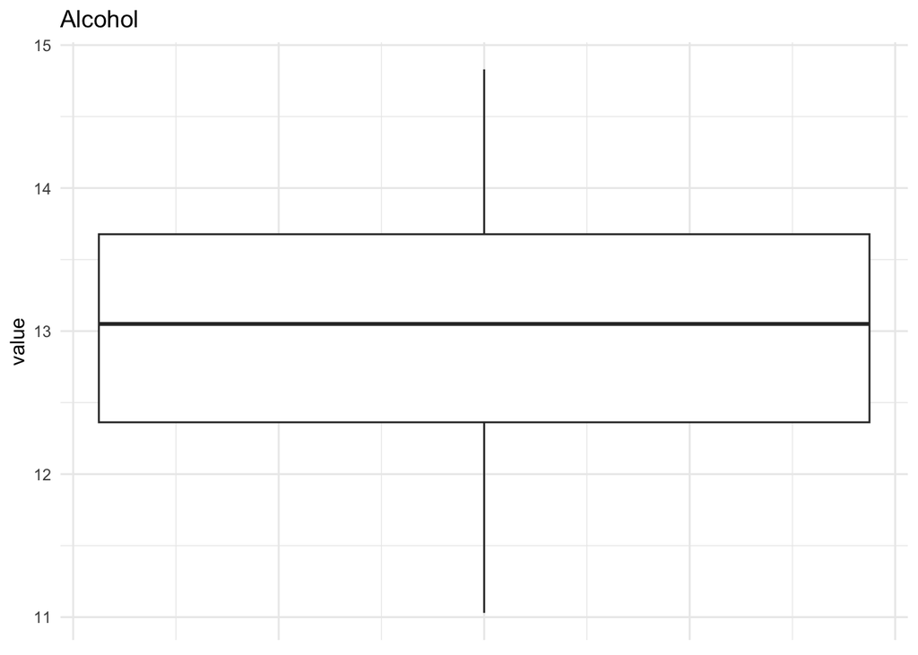

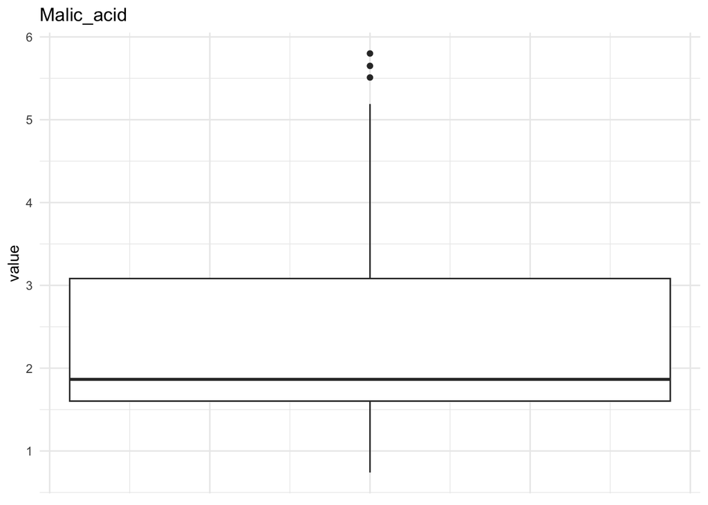

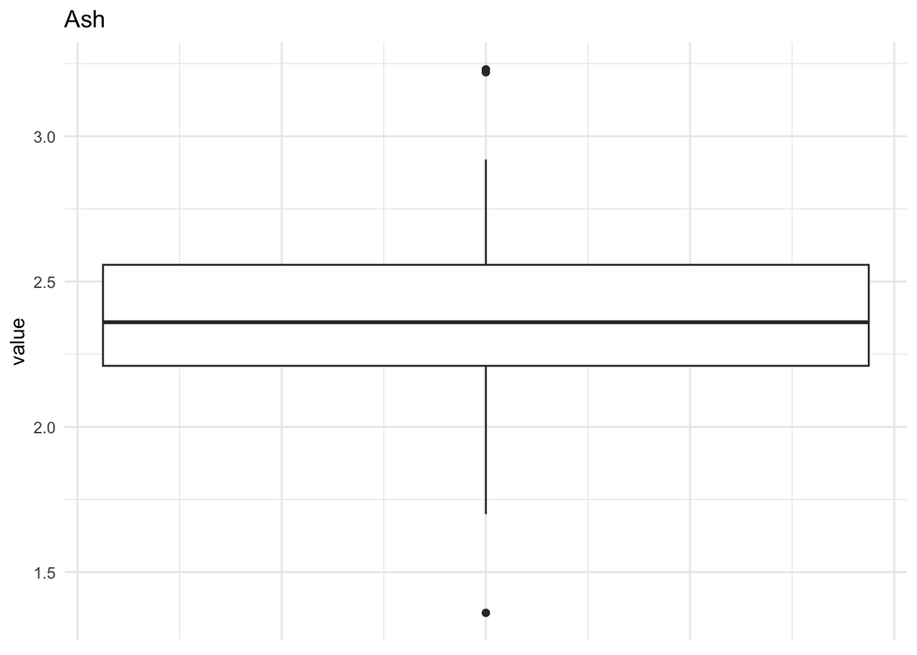

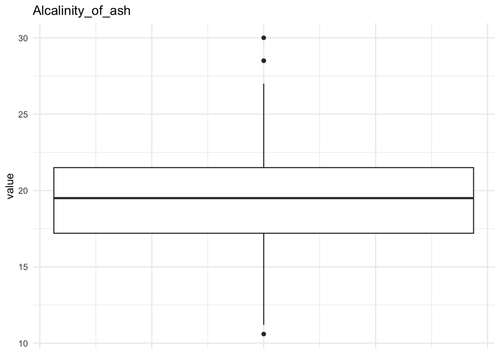

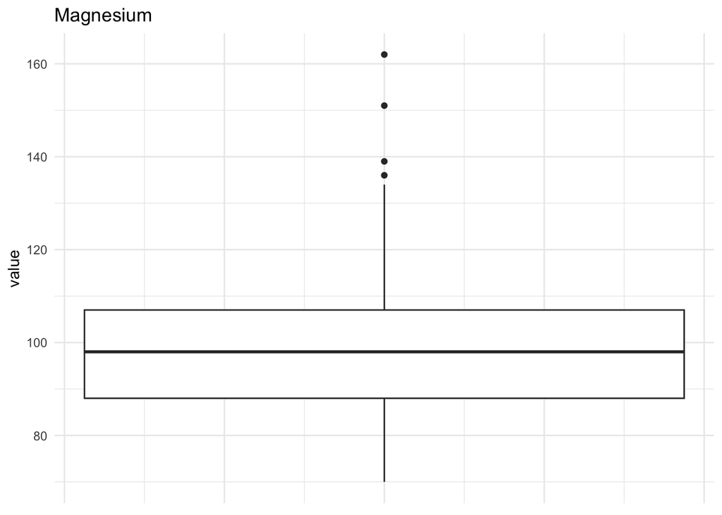

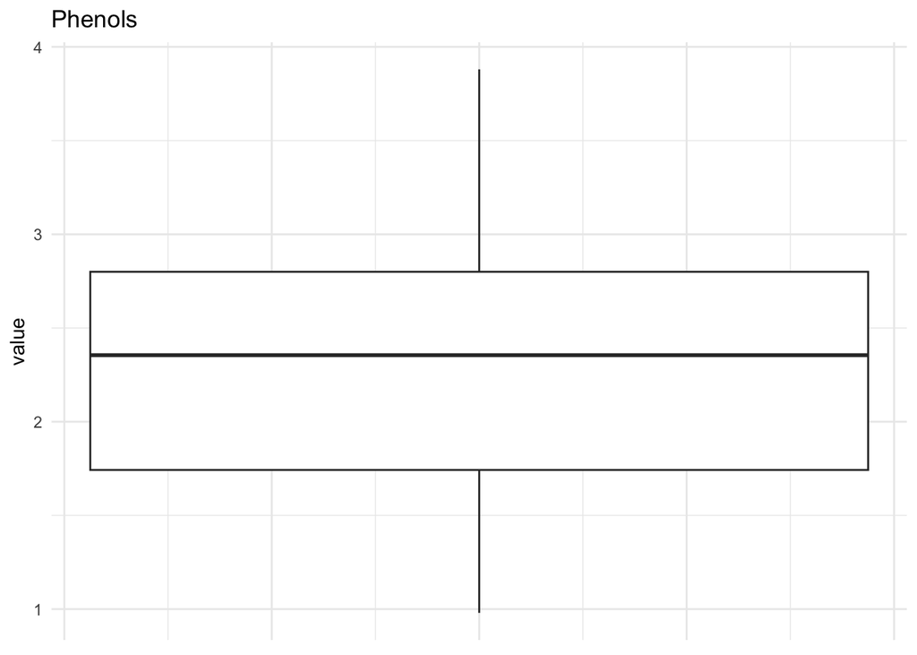

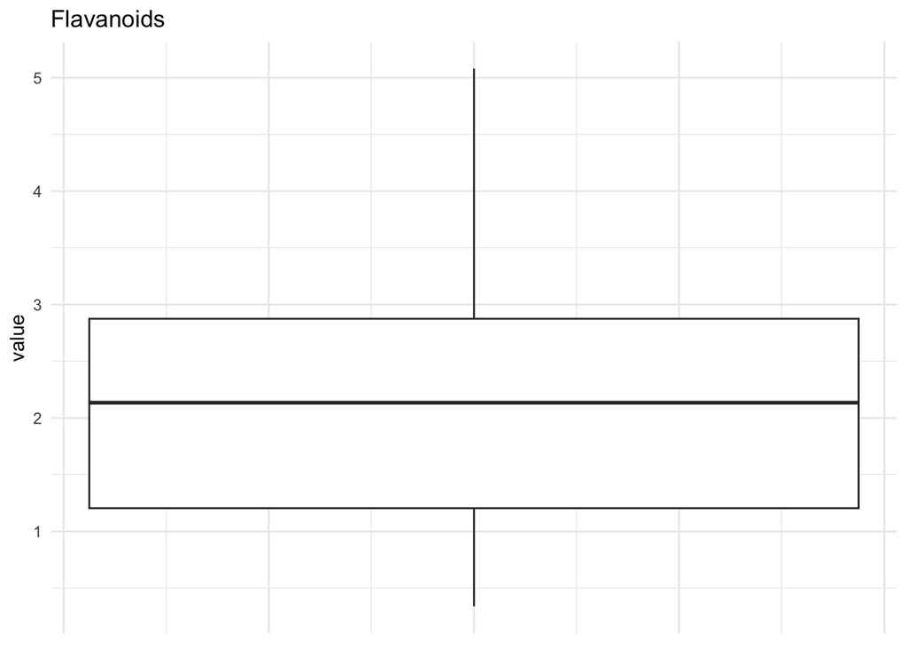

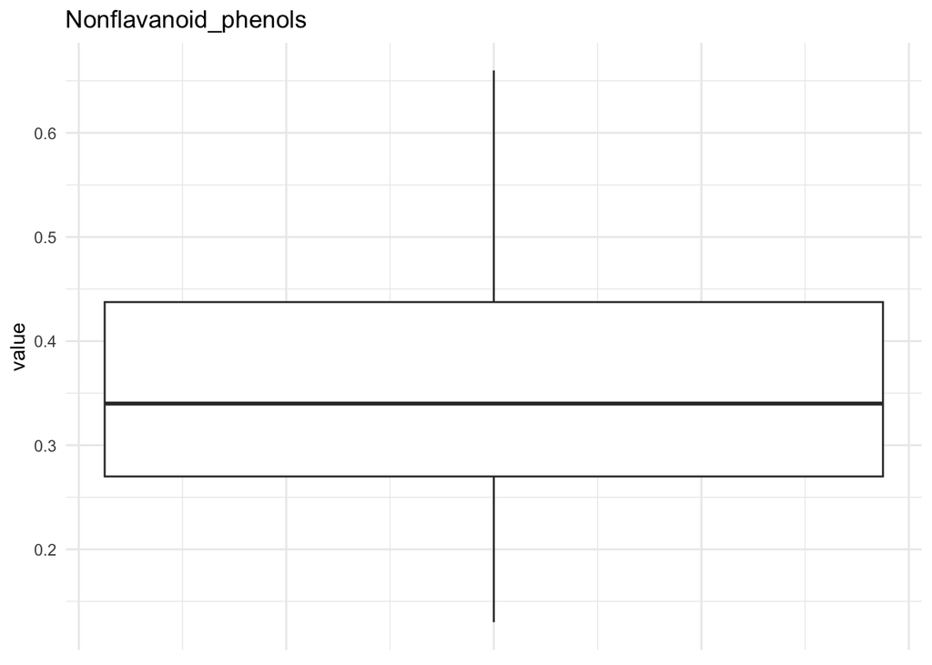

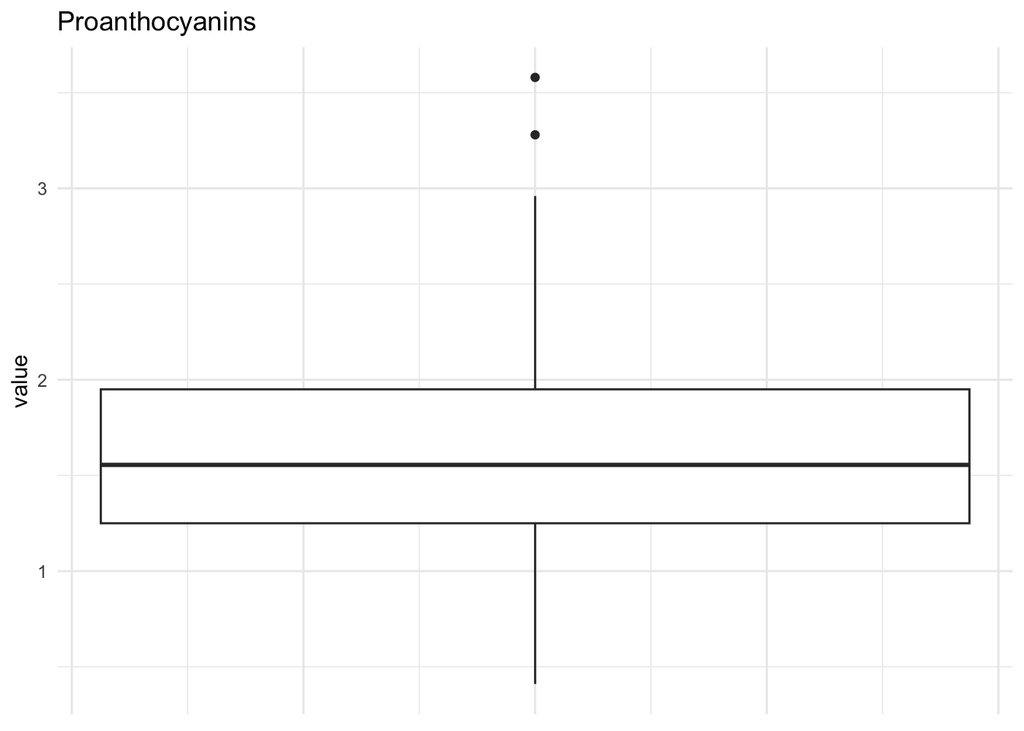

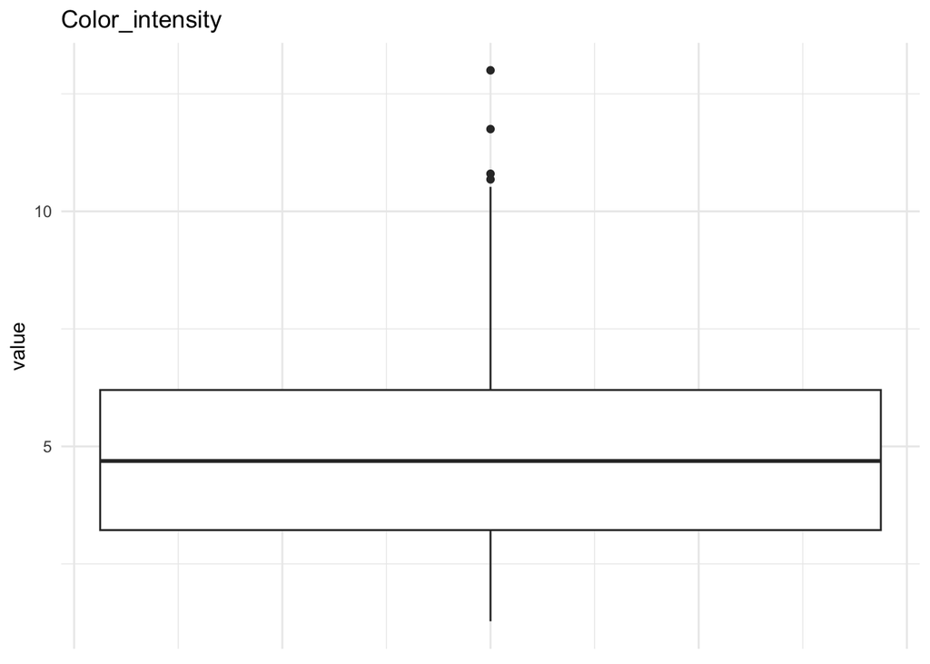

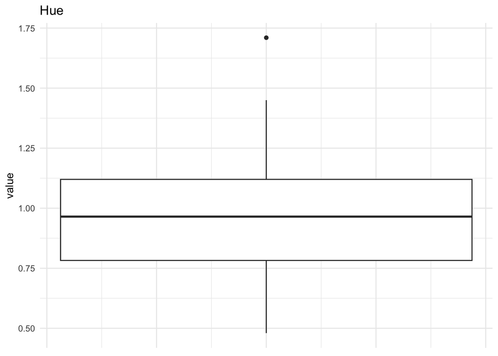

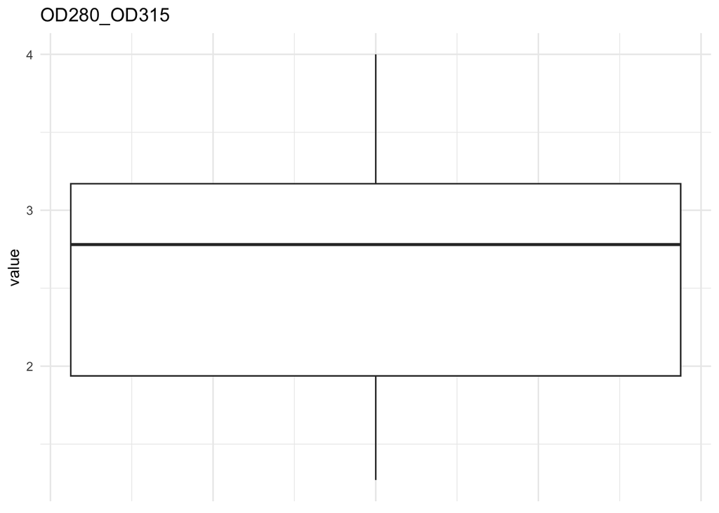

[1 more figures not shown]

```r
# Print all boxplots
for (variable in names(numerical_vars)) {
  print(boxplots_list[[variable]])
}
```

**Observations**:

The dataset comprises 13 numerical variables related to various chemical properties of wine. The sample size (n) for each variable is not explicitly mentioned in the provided output, but we can infer that the data represents a considerable number of observations given the detailed descriptive statistics for each variable. Descriptive statistics, including mean, median, standard deviation, and interquartile range, provide insights into the central tendency and variability of each variable. Box plots for each numerical variable visually showcase the distribution, highlighting potential outliers and the spread of the data. The variables cover a range of measures, from alcohol content to color intensity and proline levels, offering a comprehensive overview of the chemical composition of the wines.

The descriptive statistics and box plots reveal valuable information about the wine dataset. For instance, looking at the ‘Alcohol’ variable, the mean and median are close, indicating a symmetric distribution. The low standard deviation suggests a narrow spread around the mean, reflecting consistent alcohol content across the dataset. In contrast, variables like ‘Magnesium’ and ‘Color Intensity’ exhibit larger standard deviations, indicating higher variability.

Examining relationships between variables, we might observe potential correlations. For instance, ‘Flavanoids’ and ‘Phenols’ might exhibit a positive correlation, as higher flavonoid content could contribute to higher phenolic content. Further statistical analyses, such as correlation coefficients, could confirm these potential associations.

Understanding the descriptive statistics and visualizing the data through box plots allows us to discern patterns, trends, and potential outliers in the wine dataset. This knowledge forms the basis for more in-depth analyses, such as multivariate exploration or predictive modeling, contributing to a comprehensive understanding of the wine chemical composition.

**Task 2**  
**Description of task**:

```r
# Assuming 'result_table' from Task 1 contains the categories and frequencies
# Extracting unique wine types
wine_types <- unique(wine_data$Wine_type)

# Create a data frame to store the probability table
probability_table <- data.frame(
  Wine_Type = character(),
  Frequency = numeric(),
  Cumulative_Frequency = numeric(),
  Probability = numeric(),
  Cumulative_Probability = numeric(),
  stringsAsFactors = FALSE
)


# Calculate frequencies, cumulative frequencies, probabilities, and cumulative probabilities
total_obs <- nrow(wine_data)  # Total number of observations in the 'wine_data' dataset
cumulative_freq <- 0

for (wine_type in wine_types) {
  freq <- sum(wine_data$Wine_type == wine_type)
  cumulative_freq <- cumulative_freq + freq
  prob <- freq / total_obs
  cumulative_prob <- cumulative_freq / total_obs

  probability_table <- rbind(probability_table, c(wine_type, freq, cumulative_freq, prob, cumulative_prob))
}

# Display the probability table using kable and kableExtra
colnames(probability_table) <- c("Wine_Type", "Frequency", "Cumulative_Frequency", "Probability", "Cumulative_Probability")

probability_table %>%
  kable(align = "c",
         caption = "Probability Table for Wine Types",
         table.attr = "style='width:60%;'") %>%
  kable_classic_2(bootstrap_options = c("hover", "bordered"),
                  html_font = "Cambria",
                  position = "center",
                  font_size = 12)
```

Probability Table for Wine Types

| Wine_Type | Frequency | Cumulative_Frequency | Probability | Cumulative_Probability |
| --- | --- | --- | --- | --- |
| California | 59 | 59 | 0.331460674157303 | 0.331460674157303 |
| Washington | 71 | 130 | 0.398876404494382 | 0.730337078651685 |
| Boston | 48 | 178 | 0.269662921348315 | 1 |

**Observations about Probability Table:**

The Probability Table for Wine Types provides a detailed breakdown of the distribution of wine types in the dataset, offering insights into both individual frequencies and cumulative trends.

Examining the table, we observe three distinct wine types: California, Washington, and Boston. The ‘Frequency’ column indicates the number of observations for each wine type. For example, California has 59 occurrences, Washington has 71, and Boston has 48. The ‘Cumulative Frequency’ column displays the running total of observations up to each wine type. After California, the cumulative frequency increases to 130 with the addition of Washington and further to 178 with the inclusion of Boston.

Moving on to the ‘Probability’ column, we see the proportion of each wine type relative to the total number of observations (n=178). California constitutes approximately 33.15% of the dataset, Washington around 39.89%, and Boston approximately 26.97%. These probability values offer insights into the likelihood of encountering each wine type within the dataset.

The ‘Cumulative Probability’ column illustrates the cumulative likelihood of encountering a wine type up to a specific point in the dataset. For instance, by the end of the dataset, there is a 73.03% probability of encountering either California or Washington wines, and a 100% probability of encountering one of the three wine types.

In summary, the Probability Table serves as a comprehensive summary of the distribution of wine types, shedding light on their individual and cumulative occurrences. These insights are essential for understanding the dataset’s composition and can guide further analyses and interpretations of the wine data.

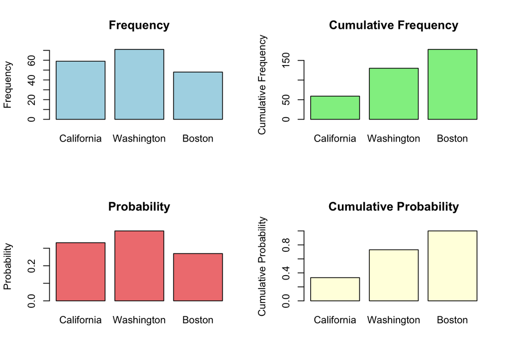

```r
par(mfrow=c(2,2))

# Create bar plot for Frequency
barplot(c(59, 71, 48), names.arg = c("California", "Washington", "Boston"),
        main = "Frequency",
        ylab = "Frequency",
        col = "lightblue")

# Create bar plot for Cumulative Frequency
barplot(c(59, 130, 178), names.arg = c("California", "Washington", "Boston"),
        main = "Cumulative Frequency",
        ylab = "Cumulative Frequency",
        col = "lightgreen")

# Create bar plot for Probability
barplot(c(0.331460674157303, 0.398876404494382, 0.269662921348315), names.arg = c("California", "Washington", "Boston"),
        main = "Probability",
        ylab = "Probability",
        col = "lightcoral")

# Create bar plot for Cumulative Probability
barplot(c(0.331460674157303, 0.730337078651685, 1), names.arg = c("California", "Washington", "Boston"),
        main = "Cumulative Probability",
        ylab = "Cumulative Probability",
        col = "lightyellow")
```

**Observations about Bar Plots:**

**Task 3**  
**Description of task**:

In this task, the objective was to compute confidence intervals for three distinct variables in the wine dataset using R. Each confidence interval serves as an estimate of the likely range within which the true mean of a specific variable lies, with varying levels of confidence.

```r
# a.
ash_ci <- t.test(wine_data$Ash, conf.level = 0.90)$conf.int

# b.
color_intensity_ci <- t.test(wine_data$Color_intensity, conf.level = 0.94)$conf.int

# c.
# Filter values for wine type California
california_phenols <- filter(wine_data, Wine_type == "California")$Phenols
phenols_ci <- t.test(california_phenols, conf.level = 0.98)$conf.int

#dataframe
confidence_intervals <- data.frame(
  Variable = c("Ash", "Color Intensity", "Phenols (California)"),
  Confidence_Level = c("90%", "94%", "98%"),
  Lower_Limit = c(ash_ci[1], color_intensity_ci[1], phenols_ci[1]),
  Upper_Limit = c(ash_ci[2], color_intensity_ci[2], phenols_ci[2])
)

# Print the results using kable
confidence_intervals %>%
  kable(align = "c",
         caption = "Confidence Intervals for Selected Variables",
         table.attr = "style='width:60%;'") %>%
  kable_classic_2(bootstrap_options = c("hover", "bordered"),
                  html_font = "Cambria",
                  position = "center",
                  font_size = 12)
```

Confidence Intervals for Selected Variables

| Variable | Confidence_Level | Lower_Limit | Upper_Limit |
| --- | --- | --- | --- |
| Ash | 90% | 2.332516 | 2.400518 |
| Color Intensity | 94% | 4.729170 | 5.387010 |
| Phenols (California) | 98% | 2.734596 | 2.945743 |

The generated confidence intervals provide crucial insights into the likely ranges of the mean values for three distinct variables within the wine dataset, each computed at varying confidence levels.

For the variable “Ash,” the 90% confidence interval (CI) spans from 2.332 to 2.401. This narrow interval indicates a high level of precision, suggesting that we can be 90% confident that the true mean of “Ash” lies within this specific range. The precision in this estimate is essential for understanding the average ash content in the dataset.

Focusing on the wine type “California” for the variable “Phenols,” the 98% CI ranges from 2.735 to 2.946. This tailored estimate offers a highly precise range for the mean phenol content in California wines, demonstrating a 98% confidence in the accuracy of this subgroup’s average. This level of certainty is particularly valuable when analyzing specific wine types.

In summary, these confidence intervals serve as powerful tools for statistical inference, providing nuanced information about the probable locations of the true means for each variable. The varying widths of the intervals reflect the trade-off between precision and confidence level. The results empower researchers and analysts to make informed interpretations about the central tendencies of the studied variables within the wine dataset.

**Task 4**  
**Description of task**:

The task involves conducting a regression analysis to explore the relationship between two variables, denoted as x and y. Specifically, we are examining the association between the variable x (Flavonoids) and y (Phenols) in the dataset. The objective is to provide a comprehensive analysis that includes correlation coefficients, determination coefficients, the linear regression formula, and a visual representation in the form of a scatter plot.

```r
# Perform regression analysis
regression_model <- lm(Phenols ~ Flavanoids, data = wine_data)

# Get correlation coefficient (r)
correlation_coefficient <- cor(wine_data$Flavanoids, wine_data$Phenols)

# Get determination coefficient (r²)
determination_coefficient <- summary(regression_model)$r.squared

# Get linear regression formula
linear_regression_formula <- as.character(as.formula(regression_model))

# Create scatter plot
scatter_plot <- ggplot(wine_data, aes(x = Flavanoids, y = Phenols)) +
  geom_point() +
  geom_smooth(method = "lm", se = FALSE, color = "blue") +
  labs(title = "Regression Analysis: Flavonoids vs. Phenols",
       x = "Flavonoids",
       y = "Phenols") +
  theme_minimal()

# Display results
cat("Correlation Coefficient (r):", correlation_coefficient, "\n")
```

```
## Correlation Coefficient (r): 0.8645635
```

```r
cat("Determination Coefficient (r²):", determination_coefficient, "\n")
```

```
## Determination Coefficient (r²): 0.74747
```

```r
cat("Linear Regression Formula:", linear_regression_formula, "\n")
```

```
## Linear Regression Formula: ~ Phenols Flavanoids
```

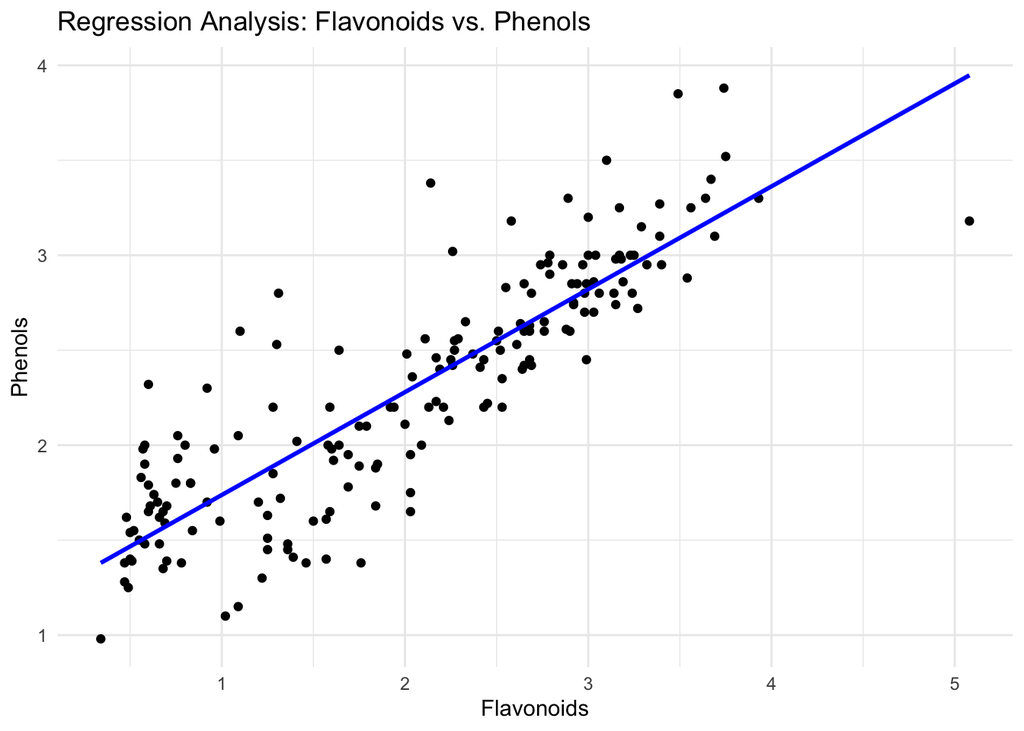

```r
# Print the scatter plot
print(scatter_plot)
```

**Observations:**

The results of the regression analysis between Flavonoids and Phenols reveal a strong positive linear relationship. The correlation coefficient (r) of 0.864 suggests a robust positive correlation between these two variables. This value, close to 1, indicates that as the Flavonoid content increases, there is a corresponding increase in Phenols. The high correlation coefficient implies a substantial degree of linear dependency between Flavonoids and Phenols in the dataset.

The determination coefficient (r²) further emphasizes the strength of this relationship. With a value of 0.747, approximately 74.7% of the variability in Phenols can be explained by the linear relationship with Flavonoids. This high determination coefficient signifies that the linear regression model effectively captures and accounts for a significant portion of the variance in Phenols based on Flavonoid levels.

The scatter plot visually reinforces the strong positive linear relationship observed between Flavonoids and Phenols. Each point on the plot represents a data pair of Flavonoid and Phenol values. The points align closely along a rising trend, indicating that as Flavonoid levels increase, Phenol concentrations consistently follow suit. The presence of a linear regression line, depicted in blue, accentuates this upward trajectory and serves as a predictive model for Phenols based on Flavonoids.

Additionally, the scatter plot highlights potential outliers or deviations from the general trend. Identifying and understanding these points could provide insights into exceptional cases or data points that deviate significantly from the established linear relationship.

**Task 5**  
**Description of task**:

The task involves conducting an exploratory analysis and statistical test to understand the relationship between wine types and the magnesium content in the dataset. A One-Way Analysis of Variance (ANOVA) is executed without the need for data filtering, directly integrating information on wine types and Magnesium levels. This statistical test seeks to ascertain whether there are significant differences in Magnesium content among the three wine types, providing a robust and data-driven evaluation of the hypothesis.

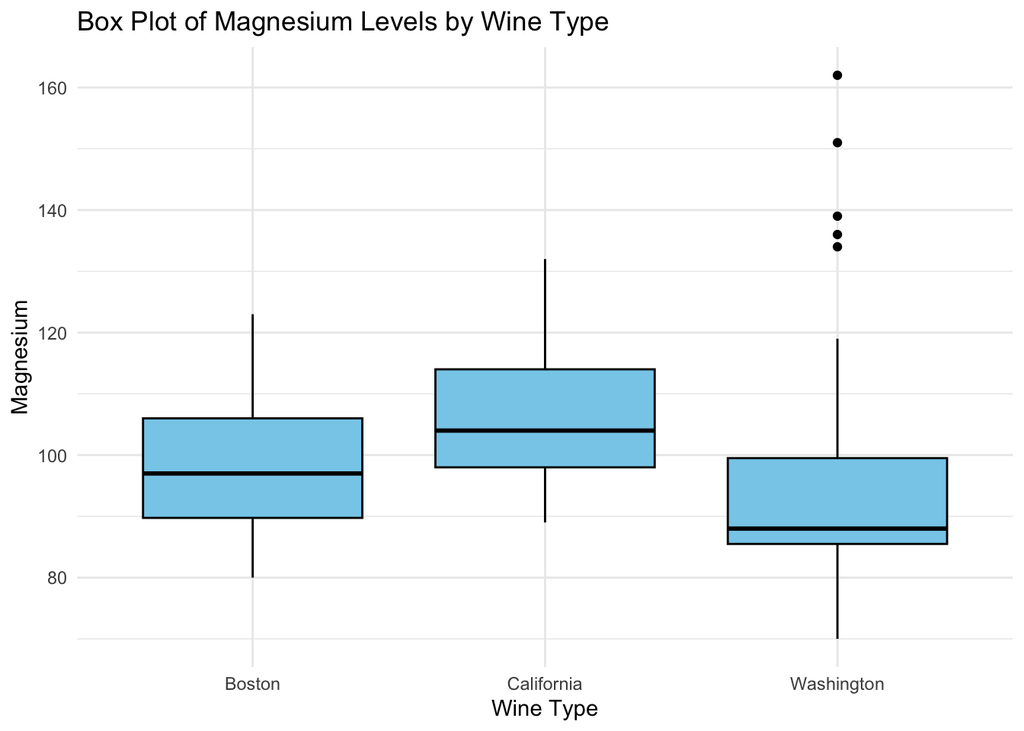

```r
# Create a box plot for Wine Type versus Magnesium
boxplot <- ggplot(wine_data, aes(x = Wine_type, y = Magnesium)) +
  geom_boxplot(fill = "skyblue", color = "black") +
  labs(title = "Box Plot of Magnesium Levels by Wine Type",
       x = "Wine Type",
       y = "Magnesium") +
  theme_minimal()

# Display the box plot
print(boxplot)
```

**why magnesium is important for wine makers and why is it used as a measure of quality:**

Magnesium holds significant importance in winemaking, affecting key aspects of the fermentation process and the overall quality of wine. Bonin’s research on the “Effects of magnesium ions on both VHG batch and continuous fruit wine fermentations” demonstrates magnesium’s essential role in yeast metabolism during fermentation, influencing sugar conversion efficiency and alcohol production (Bonin, 2014). Another study by Birch, Ciani, and Walker, titled “Magnesium, Calcium and Fermentative Metabolism in Wine Yeasts,” emphasizes magnesium’s role in maintaining yeast cell membrane integrity (Birch et al., 2003). This mineral has been identified as a cofactor for crucial enzymatic reactions, contributing to the synthesis of essential cellular components and has been linked to the enhancement of wine quality by promoting flavor stability and maturation. As a measure of quality, magnesium levels serve as valuable indicators of yeast health, fermentation vigor, and overall winemaking success.

```r
# One-Way ANOVA analysis
anova_result <- aov(Magnesium ~ Wine_type, data = wine_data)

# Print the ANOVA summary
summary(anova_result)
```

```
##              Df Sum Sq Mean Sq F value   Pr(>F)
## Wine_type     2   4491  2245.5   12.43 8.96e-06 ***
## Residuals   175  31615   180.7
## ---
## Signif. codes:  0 '***' 0.001 '**' 0.01 '*' 0.05 '.' 0.1 ' ' 1
```

**Observations:**

The One-Way ANOVA results indicate a statistically significant difference in magnesium content among the three wine types (F(2, 175) = 12.43, p < 0.001). The F-statistic of 12.43 suggests that the variability in magnesium levels between the wine types is larger than what would be expected due to random chance alone. The low p-value (8.96e-06) further supports the rejection of the null hypothesis, indicating that at least one pair of wine types has significantly different mean magnesium levels.

Post-hoc tests, such as Tukey’s Honestly Significant Difference (HSD) test, may be performed to identify which specific wine types exhibit significant differences in magnesium content. The significant result implies that wine type has a meaningful impact on magnesium levels, and further investigation into the characteristics of each wine type contributing to these differences could be valuable for winemakers.

n summary, the One-Way ANOVA provides evidence that there are significant variations in magnesium content among the wine types under study. This statistical insight contributes to a better understanding of the compositional differences in wines and may guide winemakers in optimizing magnesium levels based on the desired characteristics of the final product.

**Conclusions**  
The comprehensive analysis undertaken in this project has provided valuable insights into various aspects of the wine dataset, shedding light on both descriptive statistics and inferential analyses. The initial exploration involved calculating central tendency and dispersion measures for numerical variables, creating a robust foundation for understanding the dataset’s characteristics. The subsequent task involved crafting a well-organized table, showcasing the means, medians, standard deviations, and interquartile ranges for each numerical variable. The visual representation of selected box plots facilitated a deeper understanding of the data distribution.

Moving on to probability tables, the project delved into categorical variables, specifically wine types, elucidating their frequencies, cumulative frequencies, probabilities, and cumulative probabilities. This step not only enhanced our comprehension of wine type distribution but also set the stage for subsequent analyses.

ANOVA analysis examined the magnesium content across wine types, revealing statistically significant differences. This insight is pivotal for winemakers seeking to optimize magnesium levels based on wine type characteristics. Finally, the project concludes with a reflection on new skills acquired throughout the analysis, emphasizing the proficiency gained in employing statistical techniques, crafting visualizations, and interpreting results.

In conclusion, this project serves as a comprehensive exploration of descriptive and inferential statistics applied to a wine dataset. The results provide actionable insights for winemakers and contribute to a broader understanding of the dataset’s nuances. The project’s direction was guided by a systematic approach, ensuring a holistic analysis and interpretation of the data. The journey through various statistical methods has not only deepened our statistical knowledge but has also equipped us with practical skills applicable to real-world data analysis scenarios.

**Bibliography**  
**References**:

1. Adane, K., Gizachew, M., & Kendie, S. (2019). The role of medical data in efficient patient care delivery: a review. Risk Management and Healthcare Policy, 12, 67-73. https://doi.org/10.2147/RMHP.S179259
2. Fawcett, T. (2013). Data Science for Business. O’Reilly Media Inc.
3. Rayan, R. A., Tsagkaris, C., Zafar, I., Moysidis, D. V., & Papazoglou, A. S. (2022). Big data analytics for health: a comprehensive review of techniques and applications. In P. Keikhosrokiani (Ed.), Big Data Analytics for Healthcare (pp. 83-92). Academic Press.
4. Montgomery, D. C. (2022). Design and Analysis of Experiments. Eighth edition. Wiley. ISBN: 978-1-118-14692-7
5. Kenton, W. (2023, June 12). Analysis of Variance (ANOVA) Explanation, Formula, and Applications. Investopedia. https://www.investopedia.com/terms/a/anova.asp
6. Britannica. (2023, December 8). ANOVA. Encyclopedia Britannica. https://www.britannica.com/topic/variance-analysis-statistics
7. Majaski, C. (2023, June 22). Hypothesis to Be Tested: Definition and 4 Steps for Testing with Example. Investopedia. https://www.investopedia.com/hypothesis-to-be-tested-5179793
8. Horsch, A. (2021, May 24). Hypothesis testing for data scientists: The frequentist approach. Towards Data Science. https://towardsdatascience.com/hypothesis-testing-for-data-scientists-the-frequentist-approach-760cd9eada0b
9. Qsutra. (n.d.). Understand the Application of ANOVA in Manufacturing Process! https://qsutra.com/anova-in-manufacturing-process/
10. Visual South. (2022, March 30). Manufacturing Variance Analysis: How & Why to Run One. https://www.visualsouth.com/blog/manufacturing-variance
11. Bonin, S. (2014). Effects of magnesium ions on both VHG batch and continuous fruit wine fermentations. Journal of Industrial Microbiology & Biotechnology, 41(11), 1711–1719. https://doi.org/10.1007/s10295-014-1492-5

12.Birch, R. M., Ciani, M., & Walker, G. M. (2003). Magnesium, Calcium and Fermentative Metabolism in Wine Yeasts. Journal of Wine Research, 14(1), 1–17. https://doi.org/10.1080/0957126032000114973